# Higgs Classification

In this project we are going to look at an inclusive search for the standard model Higgs boson in pp collisions at √ s = 13 TeV at the LHC using simulated data [A. Schuy]. The Higgs bosons are produced with large transverse momentum (pT) and decaying to a bottom quark-antiquark pair. The Higgs candidates could be reconstructed as large-radius jets using Calorimeters. Due to large QCD backgorund containmination, the direct 5-sigma observation of this Higgs channel is not accomplished yet[Phys. Rev. Lett. 120, 071802 (2018)]. We are going to use a set of training datasets to optimize event selections in order to enhance the discovery sensitivity. The optimal event selections will be applied to a selected pseudo-experiment data.

# What is the LHC?

The Large Hadron Collider (LHC) is the world's largest and highest-energy particle collider and the largest machine in the world. It was built by the European Organization for Nuclear Research (CERN) between 1998 and 2008 in collaboration with over 10,000 scientists and hundreds of universities and laboratories, as well as more than 100 countries. It lies in a tunnel 27 kilometres (17 mi) in circumference and as deep as 175 metres (574 ft) beneath the France–Switzerland border near Geneva.

First collisions were achieved in 2010 at an energy of 3.5 teraelectronvolts (TeV) per beam, about four times the previous world record. After upgrades it reached 6.5 TeV per beam (13 TeV total collision energy, the present world record). At the end of 2018, it entered a two-year shutdown period for further upgrades.

The collider has four crossing points, around which are positioned seven detectors, each designed for certain kinds of research. The LHC primarily collides proton beams, but it can also use beams of heavy ions: lead–lead collisions and proton–lead collisions are typically done for one month per year. The aim of the LHC's detectors is to allow physicists to test the predictions of different theories of particle physics, including measuring the properties of the Higgs boson and searching for the large family of new particles predicted by supersymmetric theories, as well as other unsolved questions of physics.

# What is the Higgs Boson?

The Higgs boson is an elementary particle in the Standard Model of particle physics, produced by the quantum excitation of the Higgs field, one of the fields in particle physics theory. It is named after physicist Peter Higgs, who in 1964, along with five other scientists, proposed the Higgs mechanism to explain why particles have mass. This mechanism implies the existence of the Higgs boson. The Higgs boson was initially discovered as a new particle in 2012 by the ATLAS and CMS collaborations based on collisions in the LHC at CERN, and the new particle was subsequently confirmed to match the expected properties of a Higgs boson over the following years.

On 10 December 2013, two of the physicists, Peter Higgs and François Englert, were awarded the Nobel Prize in Physics for their theoretical predictions. Although Higgs's name has come to be associated with this theory (the Higgs mechanism), several researchers between about 1960 and 1972 independently developed different parts of it.

In mainstream media the Higgs boson has often been called the "God particle", from a 1993 book on the topic, although the nickname is strongly disliked by many physicists, including Higgs himself, who regard it as sensationalism.

- The Standard Model
  - Physicists explain the properties of forces between elementary particles in terms of the Standard Model – a widely accepted framework for understanding almost everything in physics in the known universe, other than gravity. (A separate theory, general relativity, is used for gravity.) In this model, the fundamental forces in nature arise from properties of our universe called gauge invariance and symmetries. The forces are transmitted by particles known as gauge bosons.
- The problem of gauge boson mass
  - Field theories had been used with great success in understanding the electromagnetic field and the strong force, but by around 1960 all attempts to create a gauge invariant theory for the weak force (and its combination with fundamental force electromagnetism, the electroweak interaction) had consistently failed, with gauge theories thereby starting to fall into disrepute as a result. The problem was that gauge invariant theory contains symmetry requirements, and these incorrectly predicted that the weak force's gauge bosons (W and Z) should have zero mass. It is known from experiments that they have non-zero mass. This meant that either gauge invariance was an incorrect approach, or something else – unknown – was giving these particles their mass. By the late 1950s, physicists had not resolved these issues and were still unable to create a comprehensive theory for particle physics, because all attempts to solve this problem just created more theoretical problems.
- Symmetry breaking
  - In the late 1950s, Yoichiro Nambu recognised that spontaneous symmetry breaking, a process where a symmetric system ends up in an asymmetric state, could occur under certain conditions. In 1962 physicist Philip Anderson, working in the field of condensed matter physics, observed that symmetry breaking played a role in superconductivity, and may have relevance to the problem of gauge invariance in particle physics. In 1963, this was shown to be theoretically possible, at least for some limited (non-relativistic) cases.
- Higgs mechanism
  - Following the 1962 and 1963 papers, three groups of researchers independently published the 1964 PRL symmetry breaking papers with similar conclusions and for all cases, not just some limited cases. They showed that the conditions for electroweak symmetry would be "broken" if an unusual type of field existed throughout the universe, and indeed, some fundamental particles would acquire mass. The field required for this to happen (which was purely hypothetical at the time) became known as the Higgs field (after Peter Higgs, one of the researchers) and the mechanism by which it led to symmetry breaking, known as the Higgs mechanism. A key feature of the necessary field is that it would take less energy for the field to have a non-zero value than a zero value, unlike all other known fields, therefore, the Higgs field has a non-zero value (or vacuum expectation) everywhere. This non-zero value could in theory break electroweak symmetry. It was the first proposal capable of showing how the weak force gauge bosons could have mass despite their governing symmetry, within a gauge invariant theory. Although these ideas did not gain much initial support or attention, by 1972 they had been developed into a comprehensive theory and proved capable of giving "sensible" results that accurately described particles known at the time, and which, with exceptional accuracy, predicted several other particles discovered during the following years. During the 1970s these theories rapidly became the Standard Model of particle physics.
- Higgs field
  - The Standard Model includes a field of the kind needed to "break" electroweak symmetry and give particles their correct mass. This field, called the "Higgs Field", exists throughout space, and it breaks some symmetry laws of the electroweak interaction, triggering the Higgs mechanism. It therefore causes the W and Z gauge bosons of the weak force to be massive at all temperatures below an extreme high value. When the weak force bosons acquire mass, this affects the distance they can freely travel, which becomes very small, also matching experimental findings. Furthermore, it was later realised that the same field would also explain, in a different way, why other fundamental constituents of matter (including electrons and quarks) have mass. Unlike all other known fields such as the electromagnetic field, the Higgs field is a scalar field, and has a non-zero constant value in vacuum.
- The "central problem"
  - There was not yet any direct evidence that the Higgs field existed, but even without proof of the field, the accuracy of its predictions led scientists to believe the theory might be true. By the 1980s the question of whether or not the Higgs field existed, and therefore whether or not the entire Standard Model was correct, had come to be regarded as one of the most important unanswered questions in particle physics. For many decades, scientists had no way to determine whether or not the Higgs field existed, because the technology needed for its detection did not exist at that time. If the Higgs field did exist, then it would be unlike any other known fundamental field, but it also was possible that these key ideas, or even the entire Standard Model, were somehow incorrect. The hypothesised Higgs mechanism made several accurate predictions. 22 One crucial prediction was that a matching particle called the "Higgs boson" should also exist. Proving the existence of the Higgs boson could prove whether the Higgs field existed, and therefore finally prove whether the Standard Model's explanation was correct. Therefore there was an extensive search for the Higgs boson, as a way to prove the Higgs field itself existed. The existence of the Higgs field became the last unverified part of the Standard Model of particle physics, and for several decades was considered "the central problem in particle physics".

# How the LHC works?

The LHC consists of a 27-kilometre ring of superconducting magnets with a number of accelerating structures to boost the energy of the particles along the way. Inside the accelerator, two high-energy particle beams travel at close to the speed of light before they are made to collide. The LHC works essentially by firing two particles at each other at speeds close to the speed of light. In its 27km circumference there are lined nearly 9000 superconducting magnets with accelerating structures to boost the energy of the particle it encounters. The strong magnetic fields created by these magnets are used to direct two particles at opposite directions of each other to speed them up for their eventual collision at the other end of the tunnel. More specialized magnets are used closer to the collision point in order to squeeze the particles closer togther to increase the probability of them colliding. With the tiny sizes of the particles the task of having two particles collide is similar to having two needles collide at nearly the speed of light. Expanding on this, the collision of high energy particles can produce jets of elementary particles which are then sectioned off and analyzed. The idea of proving the Higgs Boson using the LHC was as follows. These scientists were proving the existence of Higgs field and if it was real then after colliding two particles at high speeds then the the higgs fielf should ripple and hopefully shoot off a particle which would then be identified as the Higgs Boson. However, another difficulty with identifying this particle was that the Higgs Boson was calculated to be unstable and disintegrate in a fraction of a second. Thus scientists were tasked with searching for the finger print of the Higgs Boson through decay products it leaves behind.

- **pt (Pt)**:
  - Corresponds to the transverse momentum in the xy-plane of the proton to proton collisions in the LHC
- **eta ($\eta$)**:
  - Pseudorapidity = $\eta \equiv -\ln \left[\tan \left({\frac {\theta }{2}}\right)\right]$, where ${\displaystyle \theta }$ is the angle between the particle three-momentum ${\displaystyle \mathbf {p} }$ and the positive direction of the beam axis.Inversely,
  - ${\displaystyle \theta =2\arctan \left(e^{-\eta }\right)}$.
  - As a function of three-momentum ${\displaystyle \mathbf {p} } $, pseudorapidity can be written as
  - ${\displaystyle \eta ={\frac {1}{2}}\ln \left({\frac {\left|\mathbf {p} \right|+p_{\text{L}}}{\left|\mathbf {p} \right|-p_{\text{L}}}}\right)=\operatorname {arctanh} \left({\frac {p_{L}}{\left|\mathbf {p} \right|}}\right)}$
  - Pseudorapidity is a way of measuring the angle at which secondary particles emerge relative to the longitudinal axis of the collision of two particles. In this case it is the angle with respect to the axis of the colliding beams in the LHC and is 0 for angles perpendicular to the collision. The angle of the particle in the z-y plane
- **phi ($\phi$)**:
  - Azimuthal angle = $cos^-1(x/r)$
  - The azimuthal angle is the horizontal angle from the origin to the point of interest. The azimuthal angle responsible for the angle of the particle in x-y plane.
- **mass ($m$)**:
  - Invariant mass = $E^2 = P^2 + m^2$
  - invariant mass, or the intrinsic mass of the system of objects independent of the overall motion of the system.
- **ee2 ($e_2$)**:
  - 2-point ECF ratio
  - is the energy correlation function ratio for 2-point correlators. Particularly useful for quark/gluon discrimination.
  - 2-point ECF ratio is used for quark/gluon discrimination and is known as 2-point correlators.
- **ee3 ($e_3$)**:
  - 3-point ECF ratio
  - is the energy correlation function ratio for 3-point correlators. These correlators are best used for boosted W/Z/Higgs boson identification.
  - These correlators are best used for boosted W/Z/Higgs boson identification.
- **d2 (D2)**:
  - 3-to-2 point ECF ratio = $e3 / (e2)^3$
  - An interesting detail to note about the supplied equation is that it gives the ratio of e3 to e2 to the power of 3. Thus it is dependent on our results of 3-point ECF ratio as well as 2-point ECF ratio.
- **angularity**($τ$):
  - is the orientation of one feature to another at a given reference angle
- **$t_1$**:
  - 1-subjettiness
  - N-subjettiness sums the angular distances of N jet constituents to their nearest subjet axis where N is the subjet axis in a jet. At a higher level subjettiness is used to identify boosted hadronic objects such as top quarks. In this case N = 1.
- **$t_2$**:
  - 2-subjettiness
  - Subjettiness definition maintained from t1. In this case N = 2.
- **$t_3$**:
  - 3-subjettiness
  - Subjettiness definition maintained from t1. In this case N = 2.
- **$t_{21}$**:
  - 21-subjettiness = $($τ2$)/($τ1$)$
  - Subjettiness definition maintained from t1. In this case N = 2. This equation is dependent on our results of 1-subjettiness and 2-subjettiness as it is the ratio of these two.
- **$t_{32}$**:
  - 32-subjettiness= $($τ3$/($τ2$)$
  - Subjettiness definition maintained from t1. In this case N = 2. This equation is dependent on our results of 2-subjettiness and 3-subjettiness as it is the ratio of these two.
- **KtDeltaR ($KtΔR$)**:
  - Cluster sequence
  - $Δ$R of two subjets within the large-R jet

# Download the training datasets from one of the two pT-range folders.

In each folder, there are 2 files, each containing 100k jets. The signal dataset is labeled as “higgs” and the background dataset is labeled as “qcd.”

```python
# import library
import pickle
%matplotlib inline
import numpy as np
import matplotlib
import matplotlib.pyplot as plt
import scipy
from scipy import stats
import h5py
import statistics
import math
import scipy.signal
# open the file of interest, and use pickle loading
infile = open ("higgs_100000_pt_250_500.pkl",'rb') #signal
higgs = pickle.load(infile)

infile2 = open ("qcd_100000_pt_250_500.pkl",'rb')# background
qcd = pickle.load(infile2)

# list all keys of the files
print("Higgs Signal categories: ", higgs.keys())
print("QCD background categories: ", qcd.keys())
```

```
Higgs Signal categories:  Index(['pt', 'eta', 'phi', 'mass', 'ee2', 'ee3', 'd2', 'angularity', 't1',
       't2', 't3', 't21', 't32', 'KtDeltaR'],
      dtype='object')
QCD background categories:  Index(['pt', 'eta', 'phi', 'mass', 'ee2', 'ee3', 'd2', 'angularity', 't1',
       't2', 't3', 't21', 't32', 'KtDeltaR'],
      dtype='object')
```

```python
# Print two variables, mass and d2, of the first 10 jets
print('Higgs Signal two variables, mass and d2, of the first 10 jets:')
for i in range(10):
 print(higgs['mass'][i],higgs['d2'][i])
```

```
Higgs Signal two variables, mass and d2, of the first 10 jets:
125.15036485403486 1.2980200835589373
130.55267214662751 1.445626317832899
125.70306309880351 0.986596849742669
126.21585336608149 1.2184665392866647
132.18250371689544 1.2917844364435773
125.67653506886116 0.4343656746345235
127.65400794990293 0.9312049446719695
124.16656852260293 0.9493560863407668
122.13035265114684 3.0022665455324082
125.19144633816678 0.5539996032675585
```

# Exploring the Datasets

**Transverse momentum, $P_T$**

$$P_T=\sqrt{P_x^2+P_y^2}$$

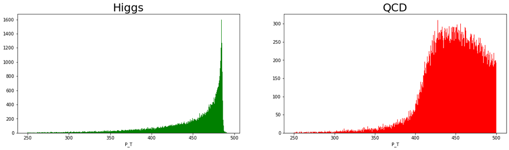

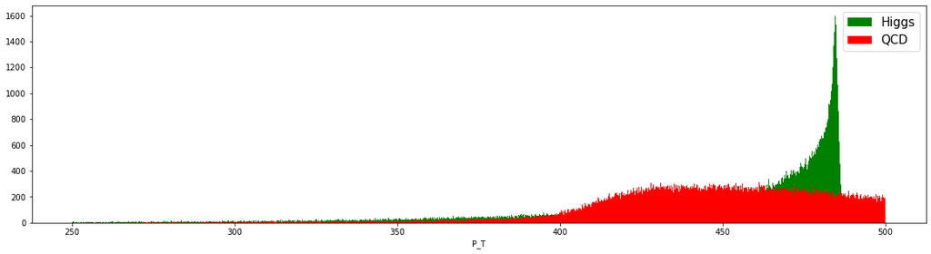

```python
hpt = higgs['pt']
qpt = qcd['pt']
fig,ax = plt.subplots(1,2,figsize=(20,5))
ax[0].hist(hpt,1000,color='g')
ax[0].set_title("Higgs",fontsize=25)
ax[0].set_xlabel("P_T",fontsize=10)
ax[1].hist(qpt,1000,color='r')
ax[1].set_title("QCD",fontsize=25)
ax[1].set_xlabel("P_T",fontsize=10)
fig,ax = plt.subplots(figsize=(20,5))
ax.hist(hpt,1000,color='g',label="Higgs")
ax.hist(qpt,1000,color='r',label="QCD")
ax.set_xlabel("P_T",fontsize=10)
ax.legend(fontsize=15);
```

Both data are from 250 to 500 $P_T$. Both Higgs and QCD are are not that good in $P_T$ with a small value. However the probability increase rapidly in $P_T$ with a big value. QCD's probability is smoothly spread over in the range 420~500, while Higgs spikes up in around 480.

**Pseudorapidity, $\eta$ & Azimuthal Angle, $\phi$**

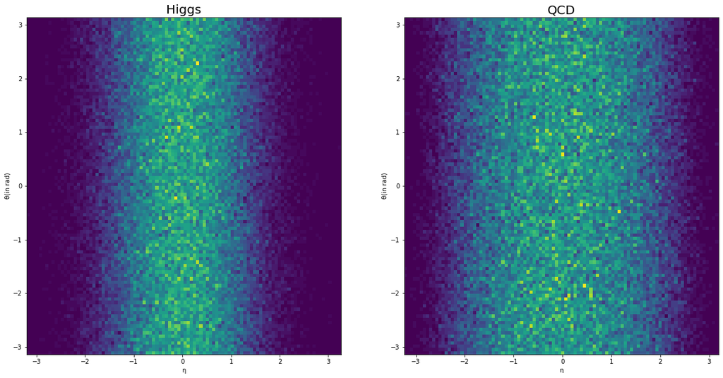

```python
Higgsta = higgs['eta']
QCDta = qcd['eta']
Higgsphi = higgs['phi']
QCDphi = qcd['phi']

fig,ax = plt.subplots(1,2,figsize=(20,10))
ax[0].hist2d(Higgsta,Higgsphi,100)
ax[0].set_title("Higgs",fontsize=20)
ax[0].set_xlabel("\u03B7",fontsize=10)
ax[0].set_ylabel("\u03B8(in rad)",fontsize=10)
ax[1].hist2d(QCDta,QCDphi,100)
ax[1].set_title("QCD",fontsize=20)
ax[1].set_xlabel("\u03B7",fontsize=10)
ax[1].set_ylabel("\u03B8(in rad)",fontsize=10);
```

**Invariant Mass, $m$**

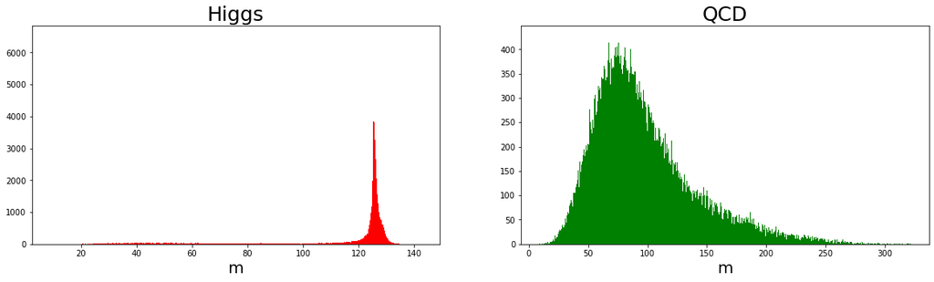

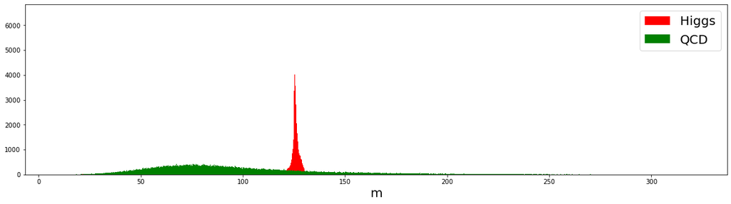

```python
Higgsmass = higgs['mass']
QCDmass = qcd['mass']
fig,ax = plt.subplots(1,2,figsize=(20,5))
ax[0].hist(Higgsmass,1000,color='r')
ax[0].set_title("Higgs",fontsize=25)
ax[0].set_xlabel("m",fontsize=20)
ax[1].hist(QCDmass,1000,color='g')
ax[1].set_title("QCD",fontsize=25)
ax[1].set_xlabel("m",fontsize=20)
fig,ax = plt.subplots(figsize=(20,5))
ax.hist(Higgsmass,1000,color='r',label="Higgs")
ax.hist(QCDmass,1000,color='g',label="QCD")
ax.set_xlabel("m",fontsize=20)
ax.legend(fontsize=20);
```

Higgs data spikes at around 125, while QCD data peaks roughly at 80 but spreads over from 25 to 200. Which means that Higgs data is the sum of data of a particle that we are aiming to get and that QCD data is a collection of the rest of the things like backgrounds.

**2&3-Point ECD ratio, $e_2,e_3$**

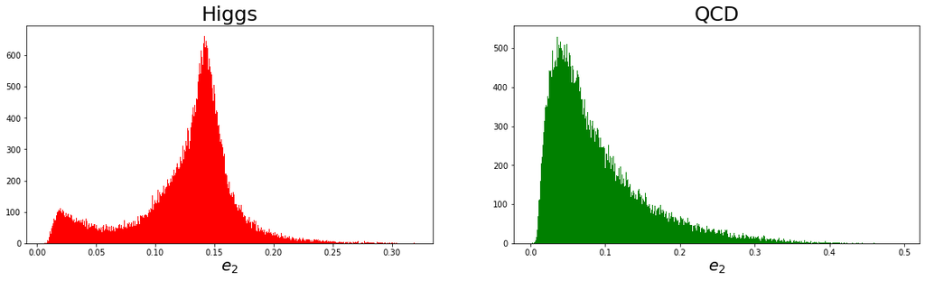

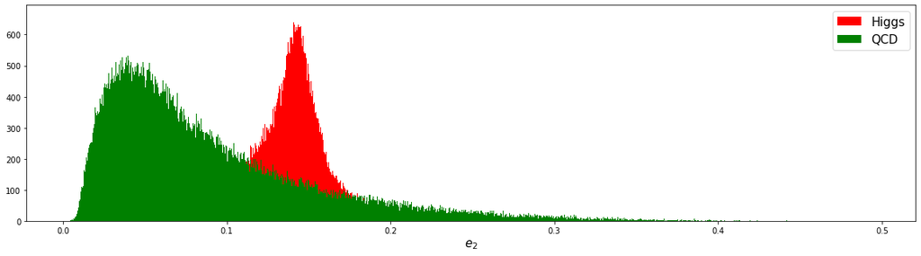

```python
Higgsee2 = higgs['ee2']
QCDee2 = qcd['ee2']
fig,ax = plt.subplots(1,2,figsize=(20,5))
ax[0].hist(Higgsee2,1000,color='r')
ax[0].set_title("Higgs",fontsize=25)
ax[0].set_xlabel("$e_2$",fontsize=20)
ax[1].hist(QCDee2,1000,color='g')
ax[1].set_title("QCD",fontsize=25)
ax[1].set_xlabel("$e_2$",fontsize=20)
fig,ax = plt.subplots(figsize=(20,5))
ax.hist(Higgsee2,1000,color='r',label="Higgs")
ax.hist(QCDee2,1000,color='g',label="QCD")
ax.set_xlabel("$e_2$",fontsize=15)
ax.legend(fontsize=15);
```

For $e_2$ data, higgs diagram shows a shape that gives a skew points at around $e_2=0.02$ and $e_2=0.15$, while QCD data is more like a rayleigh distribution with its peak at around $e_2=0.05$.

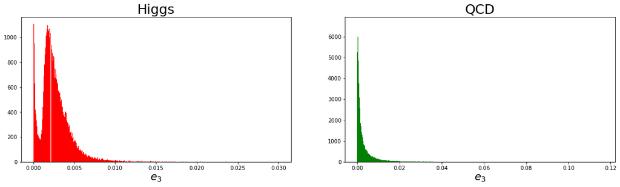

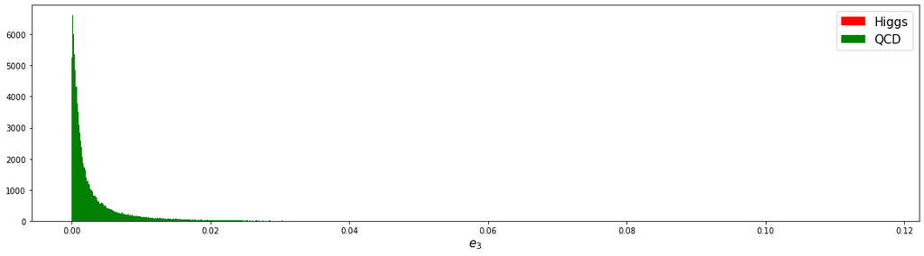

```python
Higgsee3 = higgs['ee3']
QCDee3 = qcd['ee3']
fig,ax = plt.subplots(1,2,figsize=(20,5))
ax[0].hist(Higgsee3,1000,color='r')
ax[0].set_title("Higgs",fontsize=25)
ax[0].set_xlabel("$e_3$",fontsize=20)
ax[1].hist(QCDee3,1000,color='g')
ax[1].set_title("QCD",fontsize=25)
ax[1].set_xlabel("$e_3$",fontsize=20)
fig,ax = plt.subplots(figsize=(20,5))
ax.hist(Higgsee3,1000,color='r',label="Higgs")
ax.hist(QCDee3,1000,color='g',label="QCD")
ax.set_xlabel("$e_3$",fontsize=15)
ax.legend(fontsize=15);
```

**3 to 2 Point ECF ratio, $D_2$**

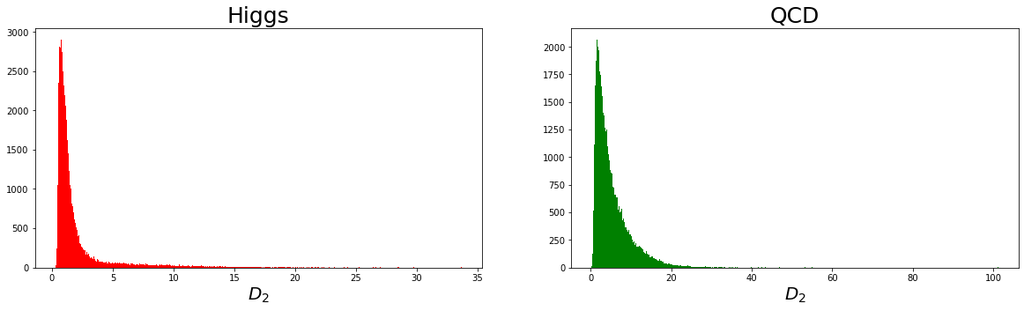

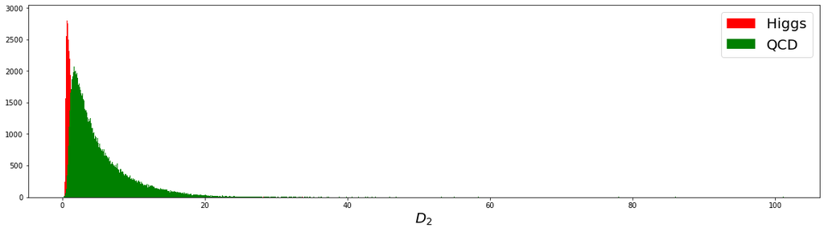

```python
Higgsd2 = higgs['d2']
QCDd2 = qcd['d2']
fig,ax = plt.subplots(1,2,figsize=(20,5))
ax[0].hist(Higgsd2,1000,color='r')
ax[0].set_title("Higgs",fontsize=25)
ax[0].set_xlabel("$D_2$",fontsize=20)
ax[1].hist(QCDd2,1000,color='g')
ax[1].set_title("QCD",fontsize=25)
ax[1].set_xlabel("$D_2$",fontsize=20)
fig,ax = plt.subplots(figsize=(20,5))
ax.hist(Higgsd2,1000,color='r',label="Higgs")
ax.hist(QCDd2,1000,color='g',label="QCD")
ax.set_xlabel("$D_2$",fontsize=20)
ax.legend(fontsize=20);
```

The two datas have the similar shapes of distributions, however Higgs data is more peaked around $D_2=1$, meaning that $e_3$ have the mostly likely the same value as $e_2$. What's more, QCD is more spread over in the region $D_2>1$, this means that $e_3$ may not be the similar value as $e_2$

**Angularity, $\tau$**

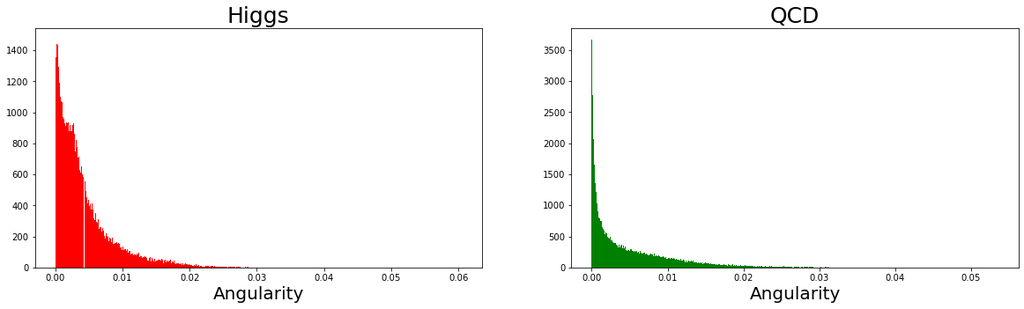

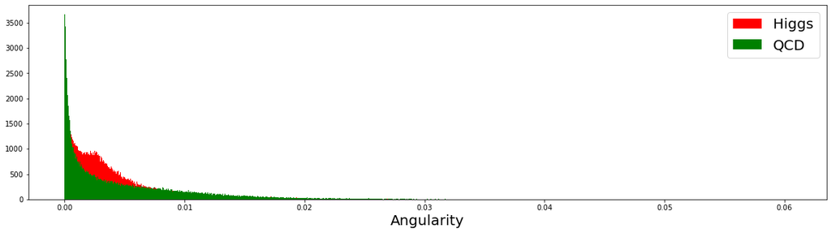

```python
Higgsang = higgs['angularity']
QCDang = qcd['angularity']
fig,ax = plt.subplots(1,2,figsize=(20,5))
ax[0].hist(Higgsang,1000,color='r')
ax[0].set_title("Higgs",fontsize=25)
ax[0].set_xlabel("Angularity",fontsize=20)
ax[1].hist(QCDang,1000,color='g')
ax[1].set_title("QCD",fontsize=25)
ax[1].set_xlabel("Angularity",fontsize=20)
fig,ax = plt.subplots(figsize=(20,5))
ax.hist(Higgsang,1000,color='r',label="Higgs")
ax.hist(QCDang,1000,color='g',label="QCD")
ax.set_xlabel("Angularity",fontsize=20)
ax.legend(fontsize=20);
```

Both distributions show the same thing, both of them have the same peak at around 0 and Higgs data has more spread over the region.

**Subjettiness,$t_1$**

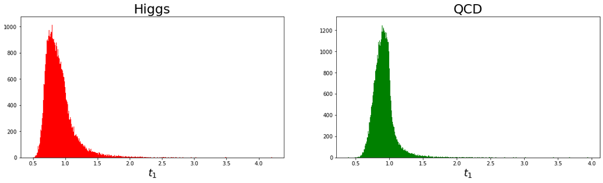

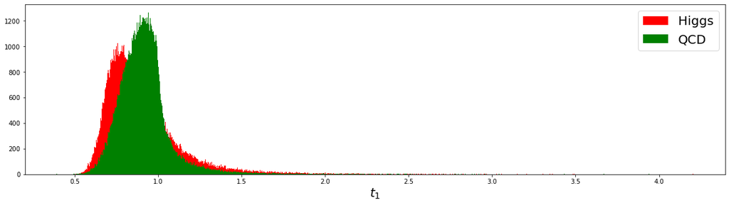

```python
Higgst1 = higgs['t1']
QCDt1 = qcd['t1']
fig,ax = plt.subplots(1,2,figsize=(20,5))
ax[0].hist(Higgst1,1000,color='r')
ax[0].set_title("Higgs",fontsize=25)
ax[0].set_xlabel("$t_1$",fontsize=20)
ax[1].hist(QCDt1,1000,color='g')
ax[1].set_title("QCD",fontsize=25)
ax[1].set_xlabel("$t_1$",fontsize=20)
fig,ax = plt.subplots(figsize=(20,5))
ax.hist(Higgst1,1000,color='r',label="Higgs")
ax.hist(QCDt1,1000,color='g',label="QCD")
ax.set_xlabel("$t_1$",fontsize=20)
ax.legend(fontsize=20);
```

Both of them show the sililar distribution and have the peak at around 0.7 to 0.9 and a spread of $0.5 - 2.5$. The difference between them is very small.

**Subjettiness,$t_2$**

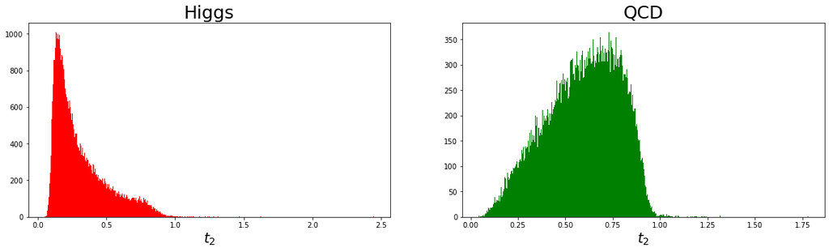

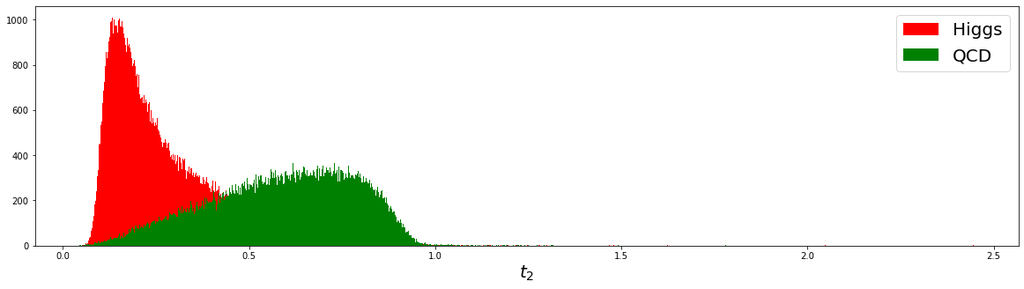

```python
Higgst2 = higgs['t2']
QCDt2 = qcd['t2']
fig,ax = plt.subplots(1,2,figsize=(20,5))
ax[0].hist(Higgst2,1000,color='r')
ax[0].set_title("Higgs",fontsize=25)
ax[0].set_xlabel("$t_2$",fontsize=20)
ax[1].hist(QCDt2,1000,color='g')
ax[1].set_title("QCD",fontsize=25)
ax[1].set_xlabel("$t_2$",fontsize=20)
fig,ax = plt.subplots(figsize=(20,5))
ax.hist(Higgst2,1000,color='r',label="Higgs")
ax.hist(QCDt2,1000,color='g',label="QCD")
ax.set_xlabel("$t_2$",fontsize=20)
ax.legend(fontsize=20);
```

The difference in $t_2$ is more obvious and the distributions on two datas are totally different. Higgs data shows that the peak is at about $t_2=0.2$, and the QCD data shows that the peak is at about $t_2=0.75$ and QCD distribution has a large spreading than that of Higgs distribution. QCD has a spreading around the region $t_2=0$ ~ $1.0$.

**Subjettiness,$𝑡_3$**

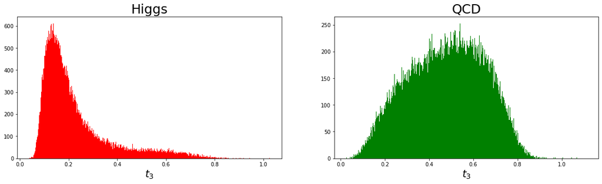

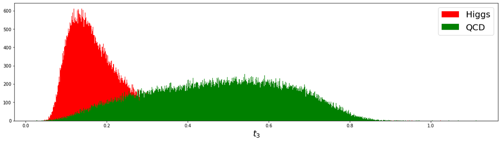

```python
Higgst3 = higgs['t3']
QCDt3 = qcd['t3']
fig,ax = plt.subplots(1,2,figsize=(20,5))
ax[0].hist(Higgst3,1000,color='r')
ax[0].set_title("Higgs",fontsize=25)
ax[0].set_xlabel("$t_3$",fontsize=20)
ax[1].hist(QCDt3,1000,color='g')
ax[1].set_title("QCD",fontsize=25)
ax[1].set_xlabel("$t_3$",fontsize=20)
fig,ax = plt.subplots(figsize=(20,5))
ax.hist(Higgst3,1000,color='r',label="Higgs")
ax.hist(QCDt3,1000,color='g',label="QCD")
ax.set_xlabel("$t_3$",fontsize=20)
ax.legend(fontsize=20);
```

**Subjettiness,$𝑡_{21}$**

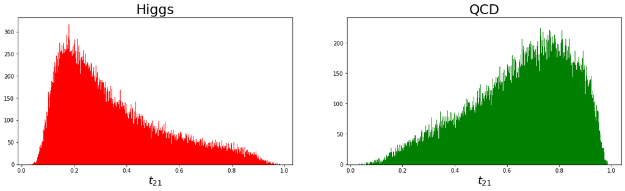

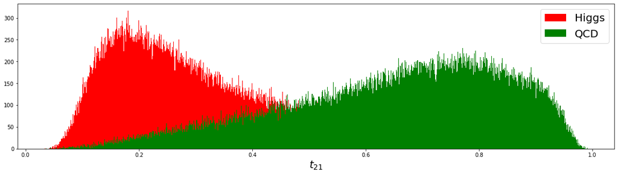

```python
Higgst21 = higgs['t21']
QCDt21 = qcd['t21']
fig,ax = plt.subplots(1,2,figsize=(20,5))
ax[0].hist(Higgst21,1000,color='r')
ax[0].set_title("Higgs",fontsize=25)
ax[0].set_xlabel("$t_{21}$",fontsize=20)
ax[1].hist(QCDt21,1000,color='g')
ax[1].set_title("QCD",fontsize=25)
ax[1].set_xlabel("$t_{21}$",fontsize=20)
fig,ax = plt.subplots(figsize=(20,5))
ax.hist(Higgst21,1000,color='r',label="Higgs")
ax.hist(QCDt21,1000,color='g',label="QCD")
ax.set_xlabel("$t_{21}$",fontsize=20)
ax.legend(fontsize=20);
```

**Subjettiness,$𝑡_{32}$**

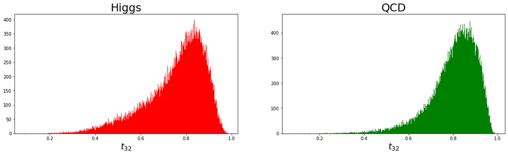

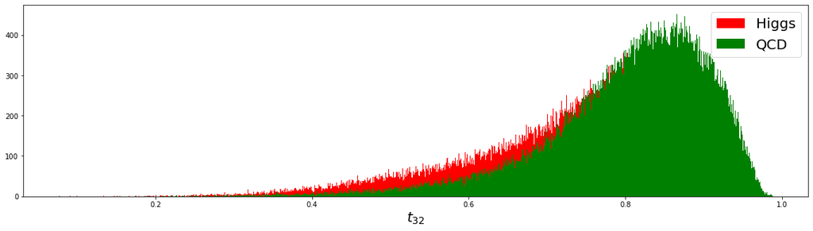

```python
Higgst32 = higgs['t32']
QCDt32 = qcd['t32']
fig,ax = plt.subplots(1,2,figsize=(20,5))
ax[0].hist(Higgst32,1000,color='r')
ax[0].set_title("Higgs",fontsize=25)
ax[0].set_xlabel("$t_{32}$",fontsize=20)
ax[1].hist(QCDt32,1000,color='g')
ax[1].set_title("QCD",fontsize=25)
ax[1].set_xlabel("$t_{32}$",fontsize=20)
fig,ax = plt.subplots(figsize=(20,5))
ax.hist(Higgst32,1000,color='r',label="Higgs")
ax.hist(QCDt32,1000,color='g',label="QCD")
ax.set_xlabel("$t_{32}$",fontsize=20)
ax.legend(fontsize=20);
```

From the graphs above, we can see that the distributions of two datas are most likely the same. The reason is that $t_2$ and $t_3$ datasets are very similar. In both Higgs and QCD, the differences between $t_3$ and $t_2$ datasets are quite the same, thus the ratio between them should more likely be close to 1.

**KtDeltaR ($KtΔR$)**

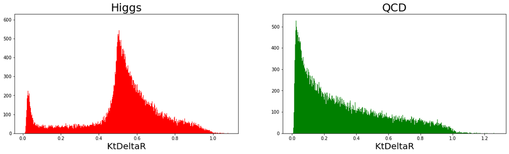

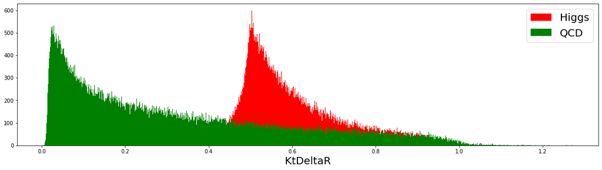

```python
HiggsKtDeltaR = higgs['KtDeltaR']
QCDKtDeltaR = qcd['KtDeltaR']
fig,ax = plt.subplots(1,2,figsize=(20,5))
ax[0].hist(HiggsKtDeltaR,1000,color='r')
ax[0].set_title("Higgs",fontsize=25)
ax[0].set_xlabel("KtDeltaR",fontsize=20)
ax[1].hist(QCDKtDeltaR,1000,color='g')
ax[1].set_title("QCD",fontsize=25)
ax[1].set_xlabel("KtDeltaR",fontsize=20)
fig,ax = plt.subplots(figsize=(20,5))
ax.hist(HiggsKtDeltaR,1000,color='r',label="Higgs")
ax.hist(QCDKtDeltaR,1000,color='g',label="QCD")
ax.set_xlabel("KtDeltaR",fontsize=20)
ax.legend(fontsize=20);
```